# Migration Flows to Europe

**Baris Alan**

Final Data Science Tutorial

CMPS 6790 / Data Science - Prof. Nicholas Mattei

[Online Access to the Project](https://barisalan00.github.io/migration-flows-europe/)

[Project Datasets](https://github.com/barisalan00/migration-flows-europe)

## Project Topic and Goals

The advanced liberal democracies in the Western world stand as an attractive destination for populations in the developing world, driven by a myriad of pull and push factors. Pull factors encompass liberal developed democracies offering employment opportunities, and providing rule of law and equal treatment before the law. Conversely, push factors comprise issues such as armed and social conflict, unemployment, poverty, corruption, poor governance, and the climate related risks. European countries, in particular, emerge as a desirable destination for numerous nations in Africa, the Middle East, and West Asia.

The primary objective of this project is to conduct a comprehensive analysis and visualization of migration flows to the European Union (EU) countries from regions outside Europe. The key areas of focus include examining the demographic structure and educational background of migrants, identifying their countries of origin and the EU countries they choose for settlement, and mapping out the migration routes and transit countries they navigate.

By addressing these aspects, the project aims to provide valuable insights into the dynamics of migration to the EU, shedding light on the factors influencing migration patterns and contributing to a nuanced understanding of the complex interplay between push and pull factors in the context of global migration.

Later on, this project builds a regression model to measure the impact and the significance of various factors on migration flows to Europe: economic (GPD per capita and multidimensional poverty), political (political stability and effectiveness of government), gender (gender inequality), conflict (armed conflict and social unrest), and climate (climate related risks).

## Project Datasets

This project will utilize various datasets from different institutions.

#### The First Dataset

The primary dataset is sourced from [Eurostat](https://ec.europa.eu/eurostat), the official statistical administration of the EU. Specifically, I obtained the dataset from the [Migration and Population Statistics](https://ec.europa.eu/eurostat/statistics-explained/index.php?title=Migration_and_migrant_population_statistics) section, focusing on [immigration by age group, sex, and citizenship](https://ec.europa.eu/eurostat/databrowser/view/migr_imm1ctz__custom_10260387/default/table?lang=en). This dataset provides the total number of migrants based on specified filters, allowing researchers to analyze immigration by receiving country, immigrant citizenship, year, age group, and gender.

Key questions addressed with the first dataset include: "What is the total number of arrivals in EU countries in 2022?", "What are the demographic characteristics of immigrants based on gender and age?", and "Which EU countries received the highest number of immigrants?", and lastly "Which sent the highest number of immigrants?"

#### The Second Set of Datasets: ISO Codes

For the second dataset, [Datahub.io](https://datahub.io/core/country-list), to incorporate 2-digit country codes, was utilized. This dataset serves the sole purpose of associating country names witb country codes in the immigration dataset.

Some of the independent variable datasets use 3-digit country codes. Therefore, for better merging the main migration dataset with these independent variable datasets, the [World Bank ISO3 Dataset](https://wits.worldbank.org/wits/wits/witshelp/content/codes/country_codes.htm) was also utilized to bring iso3 codes.

The following datasets will be used to operationalize the explanatory variables which would help to answer the main question: "What is the most important predictor of migration flows to Europe in 2022?". Therefore this project utilizes various datasets to bring independent variables into the analysis.

#### The Third-set of Datasets: Economic Indicators

To measure the effect of economic indicators, this project will utilize the GDP per capita (Purchasing Power Parity in 2017 Constant USD) dataset by the [World Bank](https://databank.worldbank.org/home). GPD/PC is the most common and one of the best indicator of overall economic wellbeing of a country.

Yet, because the average income might not reflect the well-being of the whole population, this research will include [World Bank Multidimensional Poverty Measurement](https://www.worldbank.org/en/topic/poverty/brief/multidimensional-poverty-measure) as well.

#### The Fourth Dataset: ACLED Conflict Datasets

[Armed Conflict Location & Event Data Project](https://acleddata.com/dashboard/#/dashboard) provides various datasets, ranging from mob violence to military conflict to have a sense of conflict in a specific country or region. This project will utilize three datasets which are noted as factors creating migration outflows: the Battles, Riots, and Violence against Civilians.

#### The Fifth Dataset: Governance Indicators

Sometimes goverments failure to provide services, such as health, education, or social welfare, might create dissatisfaction in public, and they might want to migrate to developed nations for these reasons. Furthermore, poor governance is also linked with worse economic outcomes and conflicts as well. [World Bank World Governance Indicator](https://www.worldbank.org/en/publication/worldwide-governance-indicators) will be used to asses the political stability and government effectiveness.

#### The Fifth Dataset: German Watch Climate Risk Index

[German Watch Climate Risk Index](https://www.germanwatch.org/en/cri) will be used to asses climate-related factors.

#### The Seventh Dataset: Population

Population of a country is also a crucial factor explaining the amount of migration flows. This project uses the [CIA's population dataset](https://www.cia.gov/the-world-factbook/field/population/).

## ETL (Extract, Transform, Load)

```python
# Import libraries
import pandas as pd
import numpy as np
import matplotlib.pyplot as plt
```

```python
# Clone the repository, change the wd
!git clone https://github.com/barisalan00/barisalan00.github.io
%cd /home/jovyan/barisalan00.github.io
!pwd
```

```
Cloning into 'barisalan00.github.io'...
remote: Enumerating objects: 141, done.
remote: Counting objects: 100% (89/89), done.
remote: Compressing objects: 100% (86/86), done.
remote: Total 141 (delta 43), reused 2 (delta 2), pack-reused 52 (from 1)
Receiving objects: 100% (141/141), 19.18 MiB | 105.00 KiB/s, done.
Resolving deltas: 100% (57/57), done.
/home/jovyan/barisalan00.github.io
/home/jovyan/barisalan00.github.io
```

### Import Datasets

```python
# Main Immigration Dataset: Import Eurostat Immigration/2022 Dataset
euim22 = pd.read_csv('Eurostat-2022Migration-migr_imm1ctz__custom_10841676_linear.csv')
display(euim22.head(3))

# Total number of observations: 119479
display(len(euim22))

# Import Datahub.io 2-digit Country Codes dataset
country_codes2 = pd.read_csv('Datahub-CountryCodes-data_csv.csv')
display(country_codes2.head(3))

# Import WB 3-digit Country Codes dataset
country_codes3 = pd.read_csv('UN-iso3.csv')
display(country_codes3.head(3))

country_codes3_ = pd.read_excel('WB-CountryCodes.xlsx')

# Economic Indicator1: WB 2022 GDP/PC
gdppc = pd.read_csv('WB-2022GDPPC-Const.csv')
display(gdppc.head(3))

# Economic Indicator2: WB 2023 Multidimensional Poverty Measure
mpm = pd.read_excel('WB-2022MPM-Data-AM2022.xlsx')
display(mpm.head(3))

# Conflict Indicator1: ACLED 2022 Battles Dataset
battle = pd.read_csv('ACLED-2022Battles.csv')
display(battle.head(3))

# Conflict Indicator2: ACLED 2022 Riots Dataset
riot = pd.read_csv('ACLED-2022Riots.csv')
display(riot.head(3))

# Conflict Indicator3: ACLED 2022 Violence Dataset
violence = pd.read_csv('ACLED-2022ViolencesCivilians.csv')
display(violence.head(3))

# Political Indicators: WB Governance Indicators
govern = pd.read_csv('WB-2022GovIndic.csv')
display(govern.head(3))

# Climate Indicator: German Watch Climate Risk Index
climate = pd.read_csv('GermanWatch-2018CRI.csv')
display(climate.head(3))

# Population Indicator: CIA World Factbook - Population
population = pd.read_csv('CIA-Population.csv', encoding='latin1')
display(population.head(3))
```

|  | DATAFLOW | LAST UPDATE | freq | citizen | agedef | age | unit | sex | geo | TIME_PERIOD | OBS_VALUE | OBS_FLAG |
| --- | --- | --- | --- | --- | --- | --- | --- | --- | --- | --- | --- | --- |
| 0 | ESTAT:MIGR_IMM1CTZ(1.0) | 27/03/24 11:00:00 | A | AD | REACH | TOTAL | NR | F | AT | 2022 | 0 | NaN |
| 1 | ESTAT:MIGR_IMM1CTZ(1.0) | 27/03/24 11:00:00 | A | AD | REACH | TOTAL | NR | F | BG | 2022 | 0 | NaN |
| 2 | ESTAT:MIGR_IMM1CTZ(1.0) | 27/03/24 11:00:00 | A | AD | REACH | TOTAL | NR | F | CZ | 2022 | 0 | NaN |

```
119479
```

|  | Name | Code |
| --- | --- | --- |
| 0 | Afghanistan | AF |
| 1 | Åland Islands | AX |
| 2 | Albania | AL |

|  | iso3 | name |
| --- | --- | --- |
| 0 | BEL | Belgium |
| 1 | CH_ | China, mainland |
| 2 | GGY | Guernsey |

|  | Country Name | Country Code | Series Name | Series Code | 2022 [YR2022] |
| --- | --- | --- | --- | --- | --- |
| 0 | Afghanistan | AFG | GDP per capita, PPP (constant 2017 internation... | NY.GDP.PCAP.PP.KD | .. |
| 1 | Africa Eastern and Southern | AFE | GDP per capita, PPP (constant 2017 internation... | NY.GDP.PCAP.PP.KD | 3566.269439 |
| 2 | Africa Western and Central | AFW | GDP per capita, PPP (constant 2017 internation... | NY.GDP.PCAP.PP.KD | 4066.48323 |

|  | Region | Country code | Economy | Reporting year | Survey name | Survey year | Survey coverage | Welfare type | Survey comparability | Monetary (%) | Educational attainment (%) | Educational enrollment (%) | Electricity (%) | Sanitation (%) | Drinking water (%) | Multidimensional poverty headcount ratio (%) |
| --- | --- | --- | --- | --- | --- | --- | --- | --- | --- | --- | --- | --- | --- | --- | --- | --- |
| 0 | ECA | ALB | Albania | 2018 | HBS | 2018 | N | c | 3.0 | 0.048107 | 0.192380 | - | 0.06025 | 6.579772 | 9.594966 | 0.293161 |
| 1 | SSA | AGO | Angola | 2018 | IDREA | 2018 | N | c | 2.0 | 31.122005 | 29.753423 | 27.44306 | 52.639532 | 53.637516 | 32.106507 | 47.203606 |
| 2 | LAC | ARG | Argentina | 2021 | EPHC-S2 | 2021 | U | i | 2.0 | 0.958847 | 1.085320 | 0.731351 | 0 | 0.193965 | 0.364048 | 0.971202 |

|  | event_id_cnty | event_date | year | time_precision | disorder_type | event_type | sub_event_type | actor1 | assoc_actor_1 | inter1 | ... | location | latitude | longitude | geo_precision | source | source_scale | notes | fatalities | tags | timestamp |
| --- | --- | --- | --- | --- | --- | --- | --- | --- | --- | --- | --- | --- | --- | --- | --- | --- | --- | --- | --- | --- | --- |
| 0 | DRC27768 | 31-Dec-22 | 2022 | 1 | Political violence | Battles | Armed clash | M23: March 23 Movement | NaN | 2 | ... | Karenga | -1.4724 | 29.0655 | 2 | Mediacongo.net; Radio Okapi | National | On 31 December 2022, during a two-day battle, ... | 0 | NaN | 1673291085 |
| 1 | MZM3154 | 31-Dec-22 | 2022 | 1 | Political violence | Battles | Armed clash | Islamist Militia (Mozambique) | NaN | 3 | ... | Namacule | -11.8567 | 39.8000 | 1 | AIM; Pinnacle News; Twitter; Zitamar | New media-National | On 31 December 2022, Islamist militia clashed ... | 2 | NaN | 1673291088 |
| 2 | MZM3155 | 31-Dec-22 | 2022 | 1 | Political violence | Battles | Armed clash | Islamist Militia (Mozambique) | NaN | 3 | ... | Namande | -11.8278 | 39.7416 | 1 | AIM; Pinnacle News; Twitter; VOA; Zitamar | New media-National | On 31 December 2022, Islamist militia clashed ... | 2 | NaN | 1673291088 |

3 rows × 31 columns

|  | event_id_cnty | event_date | year | time_precision | disorder_type | event_type | sub_event_type | actor1 | assoc_actor_1 | inter1 | ... | location | latitude | longitude | geo_precision | source | source_scale | notes | fatalities | tags | timestamp |
| --- | --- | --- | --- | --- | --- | --- | --- | --- | --- | --- | --- | --- | --- | --- | --- | --- | --- | --- | --- | --- | --- |
| 0 | KEN9717 | 31 December 2022 | 2022 | 1 | Political violence | Riots | Mob violence | Rioters (Kenya) | Vigilante Group (Kenya) | 5 | ... | Kutus | -0.5753 | 37.3269 | 2 | Kenya Standard; NTV (Kenya) | New media-National | On 31 December 2022, a mob lynched a man, part... | 1 | crowd size=no report | 1673291087 |
| 1 | BRA62473 | 31 December 2022 | 2022 | 1 | Political violence | Riots | Mob violence | Rioters (Brazil) | Vigilante Group (Brazil) | 5 | ... | Maues | -3.3795 | -57.7196 | 1 | Portal do Holanda | Subnational | On 31 December 2022, in Maues (Amazonas), a su... | 0 | crowd size=no report | 1673295343 |
| 2 | BRA62488 | 31 December 2022 | 2022 | 1 | Political violence | Riots | Mob violence | Rioters (Brazil) | PL: Liberal Party | 5 | ... | Catalao | -18.1670 | -47.9448 | 1 | Estado de Minas | National | Property destruction: On 31 December 2022, in ... | 0 | crowd size=no report | 1673295343 |

3 rows × 31 columns

|  | event_id_cnty | event_date | year | time_precision | disorder_type | event_type | sub_event_type | actor1 | assoc_actor_1 | inter1 | ... | location | latitude | longitude | geo_precision | source | source_scale | notes | fatalities | tags | timestamp |
| --- | --- | --- | --- | --- | --- | --- | --- | --- | --- | --- | --- | --- | --- | --- | --- | --- | --- | --- | --- | --- | --- |
| 0 | DRC27766 | 31 December 2022 | 2022 | 1 | Political violence | Violence against civilians | Abduction/forced disappearance | Twirwaneho Ethnic Militia (Democratic Republic... | Banyamulenge Ethnic Militia (Democratic Republ... | 4 | ... | Mikenge | -3.4497 | 28.4476 | 1 | Kivu Times | Subnational | On 31 December 2022, Twirwaneho abducted a wom... | 0 | NaN | 1673291085 |
| 1 | SAF18067 | 31 December 2022 | 2022 | 1 | Political violence | Violence against civilians | Attack | Unidentified Armed Group (South Africa) | NaN | 3 | ... | Johannesburg | -26.2023 | 28.0436 | 1 | Zambia Reports | International | On 31 December 2022, unknown suspects shot and... | 1 | NaN | 1673291088 |
| 2 | SOM38915 | 31 December 2022 | 2022 | 1 | Political violence | Violence against civilians | Abduction/forced disappearance | Al Shabaab | NaN | 2 | ... | Ted | 4.4000 | 43.9167 | 2 | Undisclosed Source | Local partner-Other | On 31 December 2022, Al Shabaab abducted three... | 0 | NaN | 1673291088 |

3 rows × 31 columns

|  | Country Name | Country Code | Series Name | Series Code | 2022 [YR2022] |
| --- | --- | --- | --- | --- | --- |
| 0 | Afghanistan | AFG | Political Stability and Absence of Violence/Te... | PV.EST | -2.550801754 |
| 1 | Afghanistan | AFG | Voice and Accountability: Estimate | VA.EST | -1.751587272 |
| 2 | Korea, Dem. People's Rep. | PRK | Voice and Accountability: Percentile Rank | VA.PER.RNK | 0 |

|  | CRI\rRank | Country | CRI\rscore | Fatalities\rin 2018\r(Rank) | Fatalities per\r100 000 inhab-\ritants (Rank) | Losses in mil-\rlion US$ (PPP)\r(Rank) | Losses per\runit GDP in\r% (Rank) |
| --- | --- | --- | --- | --- | --- | --- | --- |
| 0 | 1 | Japan | 5.50 | 2 | 2 | 3 | 12 |
| 1 | 2 | Philippines | 11.17 | 4 | 14 | 7 | 14 |
| 2 | 3 | Germany | 13.83 | 3 | 1 | 6 | 36 |

|  | name | slug | value | date_of_information | ranking | region |
| --- | --- | --- | --- | --- | --- | --- |
| 0 | Afghanistan | afghanistan | 38,346,720 | 2022 est. | 37.0 | South Asia |
| 1 | Albania | albania | 3,095,344 | 2022 est. | 136.0 | Europe |
| 2 | Algeria | algeria | 44,178,884 | 2022 est. | 34.0 | Africa |

### Transform and Tidy Data

```python
# Check the dtypes for euim22
# The year (TIME_PERIOD) and flow (OBS_VALUE) columns are integer, and the rest is object as expected.
euim22.dtypes
```

```
DATAFLOW       object
LAST UPDATE    object
freq           object
citizen        object
agedef         object
age            object
unit           object
sex            object
geo            object
TIME_PERIOD     int64
OBS_VALUE       int64
OBS_FLAG       object
dtype: object
```

```python
# Keep only necessary columns and drop redundant ones
euim22 = euim22[['citizen', 'age', 'sex', 'geo', 'TIME_PERIOD', 'OBS_VALUE']]
euim22.head()
```

|  | citizen | age | sex | geo | TIME_PERIOD | OBS_VALUE |
| --- | --- | --- | --- | --- | --- | --- |
| 0 | AD | TOTAL | F | AT | 2022 | 0 |
| 1 | AD | TOTAL | F | BG | 2022 | 0 |
| 2 | AD | TOTAL | F | CZ | 2022 | 0 |
| 3 | AD | TOTAL | F | EE | 2022 | 0 |
| 4 | AD | TOTAL | F | FI | 2022 | 0 |

```python
# Rename columns for readability
euim22.rename(columns={'citizen':'Migrant_Citizenship',
                        'age': 'Age',
                        'sex': 'Gender',
                        'geo':'Receiving_CCode',
                        'TIME_PERIOD':'Year',
                        'OBS_VALUE':'Flow'},inplace=True)
euim22.head()
```

|  | Migrant_Citizenship | Age | Gender | Receiving_CCode | Year | Flow |
| --- | --- | --- | --- | --- | --- | --- |
| 0 | AD | TOTAL | F | AT | 2022 | 0 |
| 1 | AD | TOTAL | F | BG | 2022 | 0 |
| 2 | AD | TOTAL | F | CZ | 2022 | 0 |
| 3 | AD | TOTAL | F | EE | 2022 | 0 |
| 4 | AD | TOTAL | F | FI | 2022 | 0 |

Despite the Eurostat data dashboard displaying country names for the country codes, the downloaded dataset does not include country names. This is why I will leverage the "country_codes2" dataset from datahub.io to retrieve country names for both Citizenship and Receiving Country Code codes. This step ensures a comprehensive and accurate representation of country names in the analysis.

```python
# Bring country name information for Migrant Citizenship column (left join to keep all observations at euim_21)
euim22 = pd.merge(euim22, country_codes2, how='left', left_on='Migrant_Citizenship', right_on='Code')

# Drop the redundant "Code" column
euim22.drop('Code', axis=1, inplace=True)

# Rename the 'Name' column to 'Sending_Country'
euim22.rename(columns={'Name':'Sending_Country'}, inplace=True)

# Move Migrant_Country after Migrant_Citizenship
col = euim22.pop('Sending_Country')
euim22.insert(1, col.name, col)

euim22.head(3)
```

|  | Migrant_Citizenship | Sending_Country | Age | Gender | Receiving_CCode | Year | Flow |
| --- | --- | --- | --- | --- | --- | --- | --- |
| 0 | AD | Andorra | TOTAL | F | AT | 2022 | 0 |
| 1 | AD | Andorra | TOTAL | F | BG | 2022 | 0 |
| 2 | AD | Andorra | TOTAL | F | CZ | 2022 | 0 |

```python
# Bring country name information for Receiving Country Column (left join to keep all observations at euim_22)
euim22 = pd.merge(euim22, country_codes2, how='left',left_on='Receiving_CCode', right_on='Code')

# Drop the redundant "Code" column
euim22.drop('Code', axis=1, inplace=True)

# Rename the 'Name' column to 'Receiving_Country'
euim22.rename(columns={'Name':'Receiving_Country'}, inplace=True)

# Move Receiving_Country after Receiving_CCode
col = euim22.pop('Receiving_Country')
euim22.insert(5, col.name, col)


euim22.head(3)
```

|  | Migrant_Citizenship | Sending_Country | Age | Gender | Receiving_CCode | Receiving_Country | Year | Flow |
| --- | --- | --- | --- | --- | --- | --- | --- | --- |
| 0 | AD | Andorra | TOTAL | F | AT | Austria | 2022 | 0 |
| 1 | AD | Andorra | TOTAL | F | BG | Bulgaria | 2022 | 0 |
| 2 | AD | Andorra | TOTAL | F | CZ | Czech Republic | 2022 | 0 |

```python
# Check if we lost any cells at the merge operations.
# We had 119479 observations at the beginning, and and it is still there, we are not missing anything.
len(euim22)
```

```
119479
```

```python
# Is there any missing values under Receiving_Country?
# 'EL' is country code for Greece. Greece is using both 'GR' (in international systems) and 'EL' (in European systems) as its country code.
# 'EU27_2020' is the code for 27 EU countries.
euim22[euim22['Receiving_Country'].isna()]['Receiving_CCode'].unique()
```

```
array(['EL', 'EU27_2020'], dtype=object)
```

```python
# Fill these NaN values for 'EL' with Greece
euim22.loc[euim22['Receiving_CCode'] == 'EL', 'Receiving_Country'] = 'Greece'
euim22.loc[euim22['Receiving_CCode'] == 'EU27_2020', 'Receiving_Country'] = 'EU27'
```

```python
# Are all receiving countries EU27? Iceland, Liechstein, Norway, Switzerland are not EU27.
display(euim22['Receiving_Country'].unique())
```

```
array(['Austria', 'Bulgaria', 'Czech Republic', 'Estonia', 'Finland',
       'Croatia', 'Hungary', 'Iceland', 'Italy', 'Lithuania',
       'Luxembourg', 'Latvia', 'Netherlands', 'Norway', 'Romania',
       'Sweden', 'Slovenia', 'Slovakia', 'Spain', 'France', 'Belgium',
       'Switzerland', 'Cyprus', 'Germany', 'Denmark', 'Greece', 'EU27',
       'Ireland', 'Liechtenstein', 'Malta', 'Poland', 'Portugal'],
      dtype=object)
```

```python
# Drop these 4 countries: Now we have 27 EU countries + 1 EU27 Aggregated observation
countries_to_drop = ['Iceland', 'Liechtenstein', 'Norway', 'Switzerland']
euim22 = euim22[~euim22['Receiving_Country'].isin(countries_to_drop)]
eu27 = (euim22['Receiving_Country'].unique())
print(eu27)
```

```
['Austria' 'Bulgaria' 'Czech Republic' 'Estonia' 'Finland' 'Croatia'
 'Hungary' 'Italy' 'Lithuania' 'Luxembourg' 'Latvia' 'Netherlands'
 'Romania' 'Sweden' 'Slovenia' 'Slovakia' 'Spain' 'France' 'Belgium'
 'Cyprus' 'Germany' 'Denmark' 'Greece' 'EU27' 'Ireland' 'Malta' 'Poland'
 'Portugal']
```

```python
# Is there any NaN cells under Sending_Country column? --> 20017 observations are missing.
euim22['Sending_Country'].isna().sum()
```

```
20017
```

```python
# Let's check the unique values for these 20017 NaN observations.
euim22[euim22['Sending_Country'].isna()]['Migrant_Citizenship'].unique()
```

```
array(['AFR', 'AFR_C', 'AFR_E', 'AFR_N', 'AFR_S', 'AFR_W', 'AME', 'AME_C',
       'AME_N', 'AME_S', 'ASI', 'ASI_C', 'ASI_E', 'ASI_S', 'ASI_S_E',
       'ASI_W', 'AU_NZ', 'CC8_22_FOR', 'CRB', 'CZ_SK', 'EFTA_FOR', 'EL',
       'EU27_2020_FOR', 'EUR', 'EX_SU', 'EX_YU', 'FOR_STLS', 'MEL', 'MIC',
       'NAT', 'NEU27_2020_FOR', 'OCE', 'POL', 'RNC', 'RS_ME', 'STLS',
       'TOTAL', 'UK', 'UNK', 'XK'], dtype=object)
```

The NaN values under the "Sending_Country" column correspond to the codes displayed in the array above. Notably, these codes are not 2-digit but rather 3-digit.

As per the Eurostat system, most of these codes represent continents such as 'AFR'=Africa, 'ASI_W'=West Asia, which aggregate the sum of countries within these continents. While the immigrant numbers for continents may introduce duplicates, they remain crucial for continental flow analysis.

Additionally, specific codes represent regions such as 'AU_NZ': Australia-New Zealand, 'CC8_22_FOR':8 Candidate Countries, 'CZ_SK': Czechoslovakia, 'EFTA_FOR':European Free Trade Association Countries, 'EL':Greece, 'EU27_2020_FOR':EU27 Countries except reporting country,'EUR':Europe, 'EX_SU':Soviet Union, 'EX_YU':Yugoslavia, 'FOR_STLS':Foreign country and stateless, 'NAT': Reporting Country, 'NEU27_2020_FOR':Non-EU27 countries nor reporting country, Oceania, 'RNC': Recognized Non-Citizens, 'RS_ME':Serbia and Montenegro, 'STLS': Stateless, 'TOTAL': Total, 'UNK': Unknown, 'XK':Kosovo.

For analytical purposes, all continents and regional observations will be excluded from the primary analysis. A secondary continental dataset will be created, and these observations will be removed from the original "euim22" dataset to prevent duplication. However, 'STLS': Stateless, 'RNC': Recognized Non-Citizens, 'UNK': Unknown observations will be retained in the original dataset, as these observations are not represented under any country-observations and can be treated as distinct entities. 'EU27_2020_FOR', 'NEU27_2020_FOR', and 'TOTAL' will also kept in the dataset for calculations.

```python
# Replace the NaN Values under Migrant_Country for these ('STLS':Stateless, 'RNC':Recognized Non-Citizens and 'UNK':Unknown) under Migrant_Ciizenship
# Therefore all non-NaN observatoins under Migrant_Country column are part of our analysis.
euim22.loc[euim22[euim22['Migrant_Citizenship'] == 'STLS'].index, 'Sending_Country'] = 'Stateless'
euim22.loc[euim22[euim22['Migrant_Citizenship'] == 'RNC'].index, 'Sending_Country'] = 'Non-Citizens'
euim22.loc[euim22[euim22['Migrant_Citizenship'] == 'UNK'].index, 'Sending_Country'] = 'Unkown'
euim22.loc[euim22[euim22['Migrant_Citizenship'] == 'EU27_2020_FOR'].index, 'Sending_Country'] = 'EU27'
euim22.loc[euim22[euim22['Migrant_Citizenship'] == 'NEU27_2020_FOR'].index, 'Sending_Country'] = 'Non-EU27'
euim22.loc[euim22[euim22['Migrant_Citizenship'] == 'TOTAL'].index, 'Sending_Country'] = 'Total'
euim22.loc[euim22[euim22['Migrant_Citizenship'] == 'EL'].index, 'Sending_Country'] = 'Greece'

# How many missing values now: 15129
display(euim22['Sending_Country'].isna().sum())
```

```
15129
```

```python
# Create a 2nd dataset to keep continental observations.
euim22_continents = euim22

# Now we can delete the continent/region observations from the euim22 (which are NA observations under Sending_Country column)
euim22 = euim22.dropna(subset=['Sending_Country'])

# NEw dataframe is 93370 length.
len(euim22)
```

```
93370
```

```python
#Some extra re-naming for easier coding
euim22.loc[euim22[euim22['Age'] == 'TOTAL'].index, 'Age'] = 'Total'
euim22.loc[euim22[euim22['Gender'] == 'T'].index, 'Gender'] = 'Total'
euim22.loc[euim22[euim22['Migrant_Citizenship'] == 'TOTAL'].index, 'Migrant_Citizenship'] = 'Total'
```

## Basic Summary Statistics

**How many immigrants did arrive in the EU countries in 2022 from non-European countries?**

Our dataset (code below) reveals that the total number of arrivals to EU27 amounts to almost 7 million individuals. Among these, 4.8 million immigrants originated from non-EU27 countries, while 1.1 million arrived from other EU27 countries. Considering the challenges of managing and compiling data between 27 countries, the 300K difference between Eurostat and Frontex data is ignorable.

Germany emerges as the top destination, with a total of 2.1 million immigrants arriving, followed by Spain (1.2 million), France (430K), and Italy (410K). The table is similar if we look at the arrivals from Non-EU countries.

```python
# Total number of immigration to EU27 from and total number of immigration from non-EU27
euim22[(euim22['Sending_Country'].apply(lambda x: x in ['Total', 'EU27', 'Non-EU27'])) & (euim22['Receiving_Country']=='EU27') & (euim22['Age']=='Total') & (euim22['Gender']=='Total')].sort_values(by='Flow', ascending=False)
```

|  | Migrant_Citizenship | Sending_Country | Age | Gender | Receiving_CCode | Receiving_Country | Year | Flow |
| --- | --- | --- | --- | --- | --- | --- | --- | --- |
| 106898 | Total | Total | Total | Total | EU27_2020 | EU27 | 2022 | 6977742 |
| 78980 | NEU27_2020_FOR | Non-EU27 | Total | Total | EU27_2020 | EU27 | 2022 | 4777475 |
| 38564 | EU27_2020_FOR | EU27 | Total | Total | EU27_2020 | EU27 | 2022 | 1098032 |

```python
# Total number of arrivals by reciving EU27 countries
euim22[(euim22['Sending_Country']=='Total') & (euim22['Age']=='Total') & (euim22['Gender']=='Total')].sort_values(by='Flow', ascending=False).head(5)
```

|  | Migrant_Citizenship | Sending_Country | Age | Gender | Receiving_CCode | Receiving_Country | Year | Flow |
| --- | --- | --- | --- | --- | --- | --- | --- | --- |
| 106898 | Total | Total | Total | Total | EU27_2020 | EU27 | 2022 | 6977742 |
| 106893 | Total | Total | Total | Total | DE | Germany | 2022 | 2071690 |
| 106897 | Total | Total | Total | Total | ES | Spain | 2022 | 1258894 |
| 106900 | Total | Total | Total | Total | FR | France | 2022 | 431017 |
| 106905 | Total | Total | Total | Total | IT | Italy | 2022 | 410985 |

```python
# Total number of arrivals from non-EU27 countries
euim22[(euim22['Sending_Country']=='Non-EU27') & (euim22['Age']=='Total') & (euim22['Gender']=='Total')].sort_values(by='Flow', ascending=False).head(5)
```

|  | Migrant_Citizenship | Sending_Country | Age | Gender | Receiving_CCode | Receiving_Country | Year | Flow |
| --- | --- | --- | --- | --- | --- | --- | --- | --- |
| 78980 | NEU27_2020_FOR | Non-EU27 | Total | Total | EU27_2020 | EU27 | 2022 | 4777475 |
| 78975 | NEU27_2020_FOR | Non-EU27 | Total | Total | DE | Germany | 2022 | 1630619 |
| 78979 | NEU27_2020_FOR | Non-EU27 | Total | Total | ES | Spain | 2022 | 925587 |
| 78974 | NEU27_2020_FOR | Non-EU27 | Total | Total | CZ | Czech Republic | 2022 | 330997 |
| 78987 | NEU27_2020_FOR | Non-EU27 | Total | Total | IT | Italy | 2022 | 287010 |

```python
# Create a new dataset by dropping the 'Total', 'EU27', and 'Non-EU27' observations under 'Sending_Country', and 'EU27' under 'Receiving'
# Total number of observations decreased to 90958.
immig = euim22[~euim22['Sending_Country'].isin(['Total', 'EU27', 'Non-EU27'])]
len(immig)
```

```
90958
```

```python
# Drop 'EU27' under 'Receiving_Country'
# Total number of observations decreased to 90952.
immig = immig[~immig['Receiving_Country'].isin(['EU27'])]
len(immig)
```

```
90952
```

**Crucial Note on Migration Dataset**

The Eurostat immigration dataset offers observations that provide the total number of arrivals (including **'Total'** for total arrivals, **'EU27'** for total arrivals within the EU27, and **'Non-EU27'** for total arrivals from non-EU27 countries) enabling a comprehensive view of aggregate numbers. According to these observations the total arrivals to EU27 countries amount to 7 million, with 4.8 million originating from non-EU27 countries.

However, upon removing these 'Total' observations to eliminate duplicates and examining the total number of arrivals by filtering the receiving country, we find a significantly lower figure of 3.4 million. Of this immigration flow, 1.1 million arrivals are from other EU27 countries, while 2.2 million are from non-EU27 countries.

These numbers starkly contrast with aggregate observations from Frontex and Eurostat, primarily due to the exclusion of some Sending_Country observations in the dataset. For instance, while aggregate data suggests Germany received 2.1 million immigrants in 2022, of which 1.6 million were from non-EU countries, a closer examination of arrivals to Germany by filtering the Sending_Country reveals only 6226 migrants, recorded as Stateless or Unknown, arrived in Germany.

*This means that Germany didnot released/shared the arrivals by sending countries.* Same situation exists for some other EU member states too. Therefore, it is evident that our dataset contains missing values under the Sending_Country column, which makes it difficult to have a country-level analysis for EU members.

The datasets by various organizations and projects focusing on international migration flows, including the [International Migration Organization](https://www.iom.int/data-and-research), [Global Migration Data Portal](https://www.migrationdataportal.org/international-data?i=stock_abs_&t=2020), [UN Global Migration Database](https://www.un.org/development/desa/pd/data/international-migration-flows), [OECD International Migration Database](https://stats.oecd.org/Index.aspx?DataSetCode=MIG), and [World Bank Global Bilateral Migration](https://databank.worldbank.org/source/global-bilateral-migration) and some other independent projects and academic research, were checked. However, none of these sources provide a complete dataset of bilateral migration flows. At present, the Eurostat dataset stands as the most comprehensive option. The Eurostat officials stated that the current version of the dataset is the most comprehensive one, and the member countries have discreation not to release the full details. Therefore this project will utilize the *Total* arrivals to the **EU27** by sending cobservations, instead of having a country level analysis of the EU countries.

```python
# What is total number of arrivals? 3.4 million.
immig[(immig['Age']=='Total') & (immig['Gender']=='Total')]['Flow'].sum()
```

```
3406513
```

```python
# Total number of arrivals from EU27 countries: 1.1 million
immig[(immig['Sending_Country'].isin(eu27)) & (immig['Age']=='Total') & (immig['Gender']=='Total')]['Flow'].sum()
```

```
1171307
```

```python
# Total number of arrivals from non-EU27 countries: 2.2 million.
immig_noneu = immig[~immig['Sending_Country'].isin(eu27)]
immig_noneu[(immig_noneu['Age']=='Total') & (immig['Gender']=='Total')]['Flow'].sum()
```

```
2235206
```

```python
# Total number of arrivals in Germany from non-EU27 countries: 6226
display(immig_noneu[(immig_noneu['Receiving_Country']=='Germany') & (immig_noneu['Age']=='Total') & (immig_noneu['Gender']=='Total')]['Flow'].sum())
display(immig_noneu[immig_noneu['Receiving_Country']=='Germany']['Sending_Country'].unique())
```

```
6226
```

```
array(['Stateless', 'Unkown'], dtype=object)
```

**How does the gender distribution among immigrants break down?**

The gender breakdown holds importance for various reasons. Some groups advocate for the inclusion of women, children, and the elderly while excluding men, while others argue that there is a labor shortage in the European labor market, making adult men crucial in filling this gap. More conservative groups express concerns about the potential impact of adult male immigrants on distorting European society. Therefore, understanding the gender and age demographics is crucial to assessing the validity of such perceived threats.

```
Gender
F        1142144
M        1092917
Total    2235206
Name: Flow, dtype: int64
```

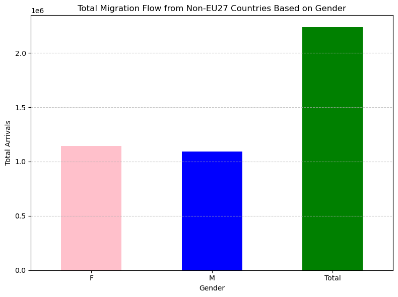

```python
# Group by 'Gender' column and sum 'Flow' column
immig_gender = immig_noneu[(immig_noneu['Age'] == 'Total')].groupby('Gender')['Flow'].sum()
print(immig_gender)

plt.figure(figsize=(8, 6))

plot_gender = immig_gender.plot(kind='bar', color=['pink','blue', 'green'])
plt.xlabel('Gender')
plt.ylabel('Total Arrivals')
plt.title('Total Migration Flow from Non-EU27 Countries Based on Gender')
plt.xticks(rotation=0)
plt.grid(axis='y', linestyle='--', alpha=0.7)
plt.tight_layout()
plt.show()
```

**What about age demographics?**

However, from a humanitarian standpoint, these figures underscore the desperation of immigrants who, in the face of civil war, economic hardships, or climate-related challenges, flee their home countries with their children, aspiring to reach Europe. Those in the age group of 20-29 are often individuals who have completed their education or recently started a family but struggle to make a living in their home countries. Frustration with poverty, corruption, and economic challenges compels them to seek better living conditions in Europe.

As future milestones incorporate additional datasets into the analysis, a clearer picture will emerge regarding the underlying reasons behind these migration patterns.

```
Age
TOTAL          NaN
Y_LT15    323229.0
Y15-19    145583.0
Y20-24    199836.0
Y25-29    258376.0
Y30-34    247847.0
Y35-39    212671.0
Y40-44    162976.0
Y45-49    117268.0
Y50-54     83435.0
Y55-59     56993.0
Y60-64     45407.0
Y_GE65     67215.0
Name: Flow, dtype: float64
```

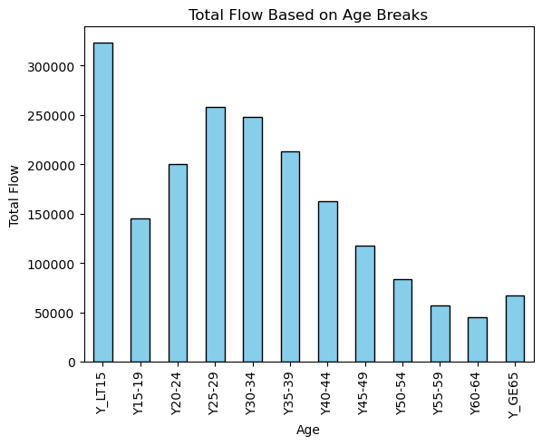

```python
# Take the total ('T') from Gender column, and groupby 'Age'.
# Y_LT15: those below 15, and Y_GE65: those above 65. Other age breaks already make sense.
# reindex the age brackets in order
immig_age = immig_noneu[(immig_noneu['Gender'] == 'Total')].groupby('Age')['Flow'].sum()

# Reindex the age breaks from smallest to biggest
display(immig_age.reindex(['TOTAL','Y_LT15', 'Y15-19', 'Y20-24', 'Y25-29', 'Y30-34', 'Y35-39', 'Y40-44', 'Y45-49', 'Y50-54', 'Y55-59', 'Y60-64', 'Y_GE65']))

#Plot
plot_age = immig_age.reindex(['Y_LT15', 'Y15-19', 'Y20-24', 'Y25-29', 'Y30-34', 'Y35-39', 'Y40-44', 'Y45-49', 'Y50-54', 'Y55-59', 'Y60-64', 'Y_GE65']).plot(kind='bar', color='skyblue', edgecolor='black')
plt.xlabel('Age')
plt.ylabel('Total Flow')
plt.title('Total Flow Based on Age Breaks')
```

**Which EU countries receive the highest number of immigrants?**

*Before going into the details it is worth reminding the limited nature of this dataset. As clarified above, Germany received a total number of 1.6 immigrants from non-EU27 countries, yet this dataset only represent 6226 immigrants.*

Additionally, the substantial influx of immigrants into Central and Eastern EU countries is noteworthy, signifying the impact of the Invasion of Ukraine. This surge in migration patterns in these regions is a notable consequence of the geopolitical events in Ukraine.

```
Receiving_Country
Spain             857915
Czech Republic    330362
Italy             283740
Netherlands       189198
Austria           115919
Romania            91019
Lithuania          66139
Sweden             54356
Hungary            43601
Croatia            40073
Estonia            38898
Finland            33014
Latvia             29800
Slovenia           24269
Luxembourg         14555
Bulgaria           13885
Germany             6226
Belgium              922
Slovakia             561
Denmark              380
Ireland              297
Poland                77
France                 0
Malta                  0
Cyprus                 0
Portugal               0
Greece                 0
Name: Flow, dtype: int64
```

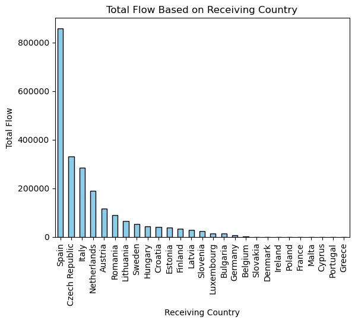

```python
# Total immigrants by receiving country
total_by_receiving = immig_noneu[(immig_noneu['Age'] == 'Total') & (immig_noneu['Gender'] == 'Total')].groupby('Receiving_Country')['Flow'].sum()

# Sort them
total_by_receiving = total_by_receiving.sort_values(ascending=False)

print(total_by_receiving)

#Plot
total_by_receiving.plot(kind='bar', color='skyblue', edgecolor='black')
plt.xlabel('Receiving Country')
plt.ylabel('Total Flow')
plt.title('Total Flow Based on Receiving Country')
```

**Which country has sent the highest number of immigrants to EU countries?**

```
Sending_Country
Ukraine                 764356
Colombia                176955
Morocco                 138886
Venezuela                85238
Peru                     74722
India                    59999
Russian Federation       52933
Argentina                49531
Pakistan                 42479
Syrian Arab Republic     42466
Name: Flow, dtype: int64
```

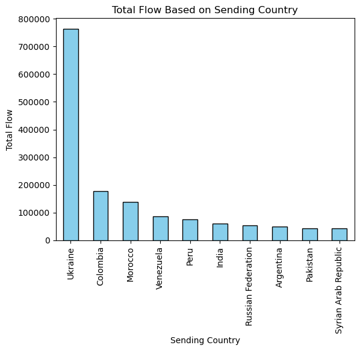

```python
# Total number of immigrants by sending country
total_by_sending = immig_noneu[(immig_noneu['Age'] == 'Total') & (immig_noneu['Gender'] == 'Total')].groupby('Sending_Country')['Flow'].sum()

# Rename countries with long names
total_by_sending.index = total_by_sending.index.str.replace('Venezuela, Bolivarian Republic of', 'Venezuela')

# Sort and display
total_by_sending = total_by_sending.sort_values(ascending=False)
display(total_by_sending.head(10))

# Plot the immigrants by top- 10 sending country
total_by_sending.head(10).plot(kind='bar', color='skyblue', edgecolor='black')
plt.xlabel('Sending Country')
plt.ylabel('Total Flow')
plt.title('Total Flow Based on Sending Country')
```

## Further ETL

As clarified above, a second goal of this project is to statistically analyze the effects of various push factors, such as economic, political, climate, and conflict, and gender-related indicators.

```python
# Keep one aggregate sums for sending countries
immigration = immig_noneu.groupby('Sending_Country').agg({'Flow': 'sum','Migrant_Citizenship': 'first'}).reset_index()
immigration
```

|  | Sending_Country | Flow | Migrant_Citizenship |
| --- | --- | --- | --- |
| 0 | Afghanistan | 53037 | AF |
| 1 | Albania | 131294 | AL |
| 2 | Algeria | 58852 | DZ |
| 3 | Andorra | 30 | AD |
| 4 | Angola | 828 | AO |
| ... | ... | ... | ... |
| 169 | Viet Nam | 22106 | VN |
| 170 | Western Sahara | 0 | EH |
| 171 | Yemen | 8918 | YE |
| 172 | Zambia | 698 | ZM |
| 173 | Zimbabwe | 1610 | ZW |

174 rows × 3 columns

```python
#Rename countries with long names
immigration['Sending_Country'] = immigration['Sending_Country'].replace({
    'Venezuela, Bolivarian Republic of': 'Venezuela',
    'Syrian Arab Republic': 'Syria',
    "Korea, Democratic People's Republic of": 'North Korea',
    'Taiwan, Province of China': 'Taiwan',
    'Holy See (Vatican City State)': 'Vatican City',
    'Tanzania, United Republic of': 'Tanzania',
    'Macedonia, the Former Yugoslav Republic of': 'Macedonia',
    'Iran, Islamic Republic of': 'Iran',
    'Bolivia, Plurinational State of': 'Bolivia'
})
```

#### Merge with Economic Indicator1: GDP/PC

GDP/PC (GDP Per Capita) Dataset has country names and 3 digit country codes. In order to merge this dataset with immigration dataset, we need 3 digit countries. Therefore, initialy the UN dataset will be used to bring the 3digit country codes for Sending_Countries.

```python
# Merge immigration dataframe with UN country_codes3
immigration = pd.merge(immigration, country_codes3, left_on='Sending_Country', right_on='name', how='left')
immigration.drop(columns=['name'], inplace=True)
immigration.rename(columns={'iso3': 'Sending_iso3'}, inplace=True)
immigration.rename(columns={'Migrant_Citizenship': 'Sending_iso2'}, inplace=True)


display(len(immigration))
immigration.head(5)
```

```
174
```

|  | Sending_Country | Flow | Sending_iso2 | Sending_iso3 |
| --- | --- | --- | --- | --- |
| 0 | Afghanistan | 53037 | AF | AFG |
| 1 | Albania | 131294 | AL | ALB |
| 2 | Algeria | 58852 | DZ | DZA |
| 3 | Andorra | 30 | AD | AND |
| 4 | Angola | 828 | AO | AGO |

```python
# Check for missing ISO3 codes: 21 missing values
display(immigration['Sending_iso3'].isna().sum())

# These countries have longer and shorter version of their names.
immigration[immigration['Sending_iso3'].isna()]['Sending_Country'].unique()
```

```
21
```

```
array(['Bolivia', 'Cape Verde', 'Congo, the Democratic Republic of the',
       'Vatican City', 'Iran', 'North Korea', 'Korea, Republic of',
       'Macedonia', 'Micronesia, Federated States of',
       'Moldova, Republic of', 'Non-Citizens', 'Palestine, State of',
       'Stateless', 'Swaziland', 'Syria', 'Taiwan', 'Tanzania', 'Turkey',
       'United States', 'Unkown', 'Venezuela'], dtype=object)
```

```python
# Manually bring the 3 digit country codes for the missing countries
missing_iso3 = {
    'Bolivia': 'BOL',
    'Congo, the Democratic Republic of the': 'COD',
    'Cape Verde': 'CPV',
    'Micronesia, Federated States of': 'FSM',
    'Syria': 'SYR',
    'Iran': 'IRN',
    'North Korea': 'PRK',
    'Korea, Republic of': 'KOR',
    'Moldova, Republic of': 'MDA',
    'Macedonia': 'MKD',
    'Palestine, State of': 'PSE',
    'Non-Citizens': 'XXX',
    'Stateless': 'XXX',
    'Swaziland': 'SWZ',
    'Turkey': 'TUR',
    'Taiwan': 'TWN',
    'Tanzania': 'TZA',
    'Unkown': 'XXX',
    'United States': 'USA',
    'Vatican City': 'VAT',
    'Venezuela': 'VEN'
}

# Update ISO3 column in immig_noneu27 dataset using the dictionary
immigration['Sending_iso3'].fillna(immigration['Sending_Country'].map(missing_iso3), inplace=True)
display(immigration['Sending_iso3'].isna().sum())
```

```
0
```

```python
# Merge WB GDP/PC with Immigration Dataset and bring GDP/PC information
immigration = pd.merge(immigration, gdppc[['Country Code', '2022 [YR2022]']], left_on='Sending_iso3', right_on='Country Code', how='left')
immigration.drop(columns=['Country Code'], inplace=True)

# Rename Sending_gdppc
immigration.rename(columns={'2022 [YR2022]': 'Sending_gdppc'}, inplace=True)

immigration
```

|  | Sending_Country | Flow | Sending_iso2 | Sending_iso3 | Sending_gdppc |
| --- | --- | --- | --- | --- | --- |
| 0 | Afghanistan | 53037 | AF | AFG | .. |
| 1 | Albania | 131294 | AL | ALB | 15491.961 |
| 2 | Algeria | 58852 | DZ | DZA | 11198.23348 |
| 3 | Andorra | 30 | AD | AND | .. |
| 4 | Angola | 828 | AO | AGO | 5906.115677 |
| ... | ... | ... | ... | ... | ... |
| 169 | Viet Nam | 22106 | VN | VNM | 11396.5313 |
| 170 | Western Sahara | 0 | EH | ESH | NaN |
| 171 | Yemen | 8918 | YE | YEM | .. |
| 172 | Zambia | 698 | ZM | ZMB | 3365.87378 |
| 173 | Zimbabwe | 1610 | ZW | ZWE | 2207.957033 |

174 rows × 5 columns

**Check the data type and unique values for `Sending_gdppc` column.**

In the dataframe above, Andorra has a value of "..", yet it is not included in missing values. It is better to check the data type of this GDP/PC column, and the unique values.

```python
# Data type of Sending_gdppc = object
print(immigration['Sending_gdppc'].dtype)

# Turn datatype of GDP/PC column into numeric
immigration['Sending_gdppc'] = pd.to_numeric(immigration['Sending_gdppc'], errors='coerce')
print(immigration.dtypes)
```

```
object
Sending_Country     object
Flow                 int64
Sending_iso2        object
Sending_iso3        object
Sending_gdppc      float64
dtype: object
```

```python
# How many NaN values under GDP/PC column
missing_gdppc = immigration[immigration['Sending_gdppc'].isna()]['Sending_Country'].unique()
display(len(missing_gdppc))
display("Countries with NaN GDP/PC: ", missing_gdppc)
```

```
24
```

```
'Countries with NaN GDP/PC: '
```

```
array(['Afghanistan', 'Andorra', 'Bhutan', 'Cuba', 'Eritrea',
       'Vatican City', 'Isle of Man', 'Jersey', 'North Korea', 'Lebanon',
       'Liechtenstein', 'Monaco', 'Non-Citizens', 'Palau', 'San Marino',
       'South Sudan', 'Stateless', 'Syria', 'Taiwan', 'Tonga', 'Unkown',
       'Venezuela', 'Western Sahara', 'Yemen'], dtype=object)
```

```python
# How many migrants arrived from these countries with missing GDP/PC column?
immigration[(immigration['Sending_Country'].isin(missing_gdppc))].groupby('Sending_Country')['Flow'].sum().sort_values(ascending=False)
```

```
Sending_Country
Venezuela         340468
Syria             138876
Cuba               82456
Afghanistan        53037
Unkown             35760
Eritrea            14295
Stateless          11142
Lebanon             9025
Yemen               8918
Non-Citizens        4090
Taiwan              3608
South Sudan          761
San Marino           118
Bhutan                98
Liechtenstein         88
North Korea           78
Andorra               30
Monaco                 6
Palau                  4
Vatican City           2
Jersey                 0
Tonga                  0
Isle of Man            0
Western Sahara         0
Name: Flow, dtype: int64
```

**Important Note on Imputation:** As it can be seen above, some of these countries with missing GDP/PC information didnot send any migrants to the EU, or only send a handful. Some of these countries geographically located in Europe and they send only a handful of migrants(Vatican City, Monaco, Andorra etc). For the purpose of this project, the GDP/PC information of the sending countries outside Europe will be brought from other reliable resources (such as IMF, and World Bank) and be kept in the dataset and whereas those in Europe will be dropped.

Besides these countries, the migrants recorded as Unknown, Stateless, and Non-Citizens also have missing GDP/PC information, because they do not have state information. For these observations we will simply replace the GDP/PC with the average GDP/PC.

```python
# Define GDP per capita values for missing countries
missing_gdp = {
    'Venezuela': 3420,
    'Syria': 752,
    'Cuba': 7449,
    'Afghanistan': 372,
    'Eritrea': 1921,
    'Lebanon': 4467,
    'Yemen': 1017,
    'Taiwan': 32716,
    'South Sudan': 340,
    'Western Sahara': 2500,
    'Tonga': 4681,
    'Palau': 14565,
    'North Korea': 1217,
    'Bhutan': 3704

}

# Fill missing GDP per capita values based on Sending_Country
immigration['Sending_gdppc'] = immigration.apply(
    lambda row: missing_gdp[row['Sending_Country']] if pd.isna(row['Sending_gdppc']) and row['Sending_Country'] in missing_gdp else row['Sending_gdppc'],
    axis=1
)

# Check the remaining missing countries
display(immigration[immigration['Sending_gdppc'].isna()]['Sending_Country'].unique())
```

```
array(['Andorra', 'Vatican City', 'Isle of Man', 'Jersey',
       'Liechtenstein', 'Monaco', 'Non-Citizens', 'San Marino',
       'Stateless', 'Unkown'], dtype=object)
```

```python
# For the Unkown, Stateless, Recognized Non-Citizens observations, fill the GDP/PC with the average of dataset
average_gdppc = immigration['Sending_gdppc'].mean()

# 3 observations
countries_to_fill = ['Unkown', 'Stateless', 'Non-Citizens']

# Fill missing GDP per capita for specified countries with the dataset's average GDP per capita
immigration['Sending_gdppc'] = immigration.apply(
    lambda row: average_gdppc if pd.isna(row['Sending_gdppc']) and row['Sending_Country'] in countries_to_fill else row['Sending_gdppc'],
    axis=1
)

# Check the remaining missing countries
display(immigration[immigration['Sending_gdppc'].isna()]['Sending_Country'].unique())
```

```
array(['Andorra', 'Vatican City', 'Isle of Man', 'Jersey',
       'Liechtenstein', 'Monaco', 'San Marino'], dtype=object)
```

```python
# Drop NA values
immigration = immigration.dropna(subset=['Sending_gdppc'])

# Verify that no missing GDP per capita values remain
immigration['Sending_gdppc'].isna().sum()
```

```
0
```

**Scatter Plot of Migration Flows and GDP/PC:** My project hypothesizes the economic conditions, GDP/PC, are the consistent and stable long-term cause of migration outflows to Europe.

An early scatterplot with regression line for the whole dataset below shows a small negative slope below, which indicates that the GDP/PC and the migration flows are negatively correlated. However, I argue that the effect would be much higher for African countries. Hence, if a dummy variable for the continent is included, or if seperate models were created for different country groups (such as African countries, Gulf countries, developed countries) then the economic conditions would have a higher negative coefficient and therefore a higher negative impact on the migration flows especially from underdeveloped and developing countries which located at the periphery of the Europe.

Individual scatter plots for each explanatory variable will be provided once all of the y-variables are merged into the main dataset.

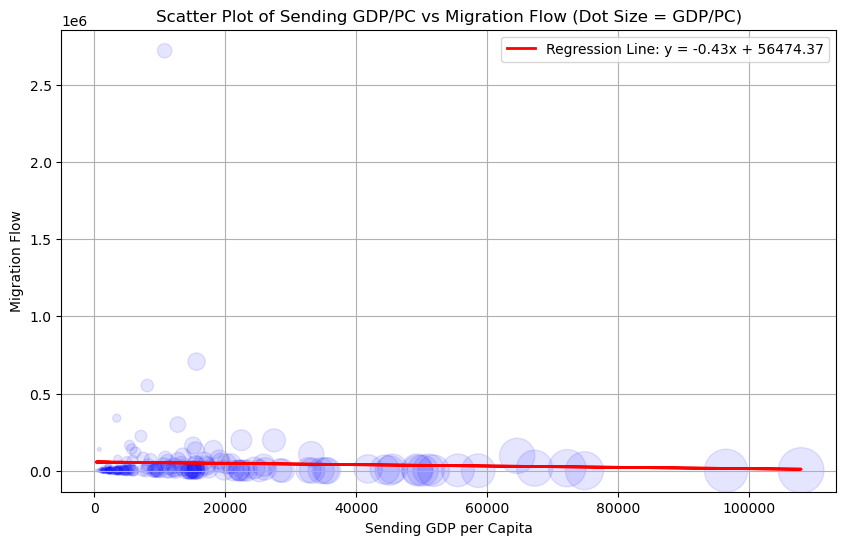

```python
import numpy as np
import matplotlib.pyplot as plt

# Scatter plot with size proportional to Flow
plt.figure(figsize=(10, 6))
plt.scatter(
    immigration['Sending_gdppc'],
    immigration['Flow'],
    s=immigration['Sending_gdppc'] / 100,  # Size of the dot
    alpha=0.1,
    color='blue'
)

# Calculate the regression line
x = immigration['Sending_gdppc']
y = immigration['Flow']
coefficients = np.polyfit(x, y, 1)
regression_line = np.poly1d(coefficients)

# Plot the regression line
plt.plot(
    x,
    regression_line(x),
    color='red',
    linewidth=2,
    label=f'Regression Line: y = {coefficients[0]:.2f}x + {coefficients[1]:.2f}'
)

# Add labels and title
plt.xlabel('Sending GDP per Capita')
plt.ylabel('Migration Flow')
plt.title('Scatter Plot of Sending GDP/PC vs Migration Flow (Dot Size = GDP/PC)')
plt.grid(True)
plt.legend()

# Show the plot
plt.show()
```